# Práctica Baterias

Luis Fernando Mamani Huanto

2023-06-05

## Caso de estudio práctico - Baterías de autoelevador

Recuperación de datos de las Baterias Varta 75

```r
datos_75 <- c(1 , 19 , 0,
2 , 18 , 0,
3 , 22 , 0,
4 , 25 , 0,
5 , 17 , 0,
6 , 30 , 0,
7 , 29 , 0,
8 , 32 , 0,
9 , 31 , 0,
10, 33 , 0,
11, 38 , 0,
12, 36 , 0,
13, 40 , 1,
14, 40 , 0,
15, 42 , 0,
16, 45 , 0,
17, 47 , 0,
18, 49 , 0,
19, 55 , 0,
20, 58 , 1,
21, 57 , 1,
22, 63 , 1,
23, 65 , 1,
24, 65 , 1,
25, 66 , 1)
Muestra_75 <- matrix(datos_75, ncol = 3, byrow = TRUE)
Muestra_75
```

```
##       [,1] [,2] [,3]
##  [1,]    1   19    0
##  [2,]    2   18    0
##  [3,]    3   22    0
##  [4,]    4   25    0
##  [5,]    5   17    0
##  [6,]    6   30    0
##  [7,]    7   29    0
##  [8,]    8   32    0
##  [9,]    9   31    0
## [10,]   10   33    0
## [11,]   11   38    0
## [12,]   12   36    0
## [13,]   13   40    1
## [14,]   14   40    0
## [15,]   15   42    0
## [16,]   16   45    0
## [17,]   17   47    0
## [18,]   18   49    0
## [19,]   19   55    0
## [20,]   20   58    1
## [21,]   21   57    1
## [22,]   22   63    1
## [23,]   23   65    1
## [24,]   24   65    1
## [25,]   25   66    1
```

Recuperación de datos de las Baterias Siemens 1005

```r
datos_1005 <- c(1 , 19 , 0,
2 , 18 , 0,
3 , 22 , 0,
4 , 25 , 0,
5 , 17 , 0,
6 , 30 , 0,
7 , 29 , 0,
8 , 32 , 0,
9 , 31 , 0,
10, 33 , 0,
11, 38 , 1,
12, 36 , 0,
13, 40 , 1,
14, 40 , 0,
15, 42 , 1,
16, 45 , 0,
17, 47 , 1,
18, 49 , 0,
19, 55 , 0,
20, 58 , 1,
21, 57 , 1,
22, 63 , 1,
23, 65 , 1,
24, 65 , 1,
25, 66 , 1,
26, 69 , 1,
27, 70 , 1,
28, 71 , 1,
29, 75 , 1,
30, 86 , 1,
31, 79 , 1,
32, 88 , 1,
33, 89 , 0,
34, 92 , 1,
35, 84 , 1)
Muestra_1005 <- matrix(datos_1005, ncol = 3, byrow = TRUE)
Muestra_1005
```

```
##       [,1] [,2] [,3]
##  [1,]    1   19    0
##  [2,]    2   18    0
##  [3,]    3   22    0
##  [4,]    4   25    0
##  [5,]    5   17    0
##  [6,]    6   30    0
##  [7,]    7   29    0
##  [8,]    8   32    0
##  [9,]    9   31    0
## [10,]   10   33    0
## [11,]   11   38    1
## [12,]   12   36    0
## [13,]   13   40    1
## [14,]   14   40    0
```

[output cut: 21 more lines]

Histograma de las Baterias Varta 75

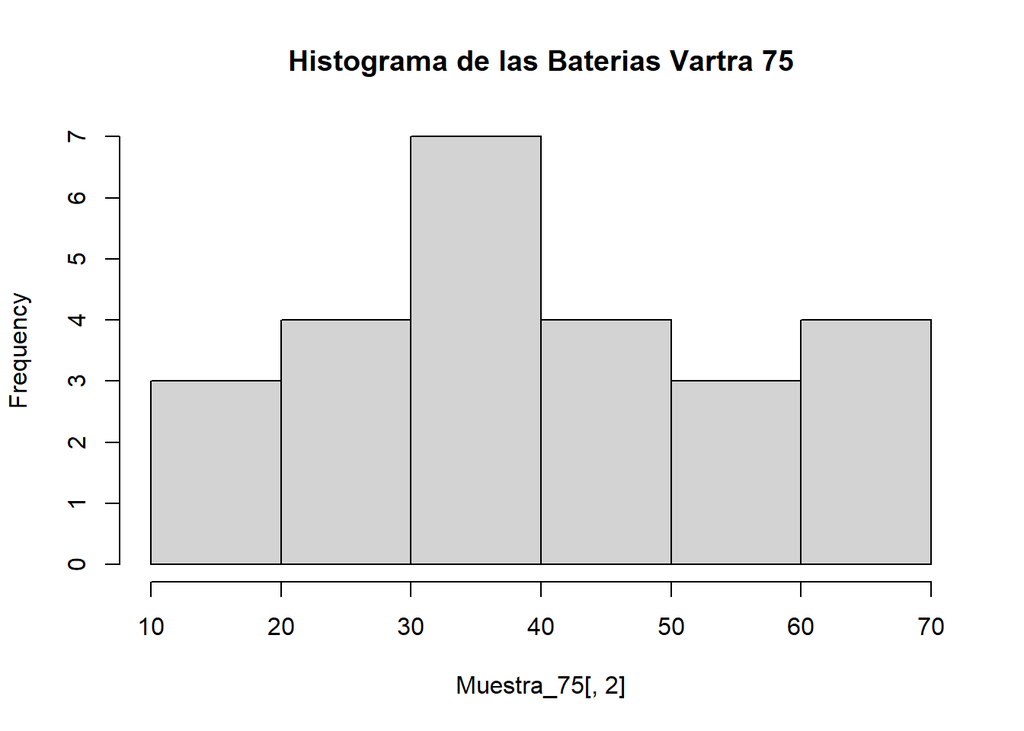

```r
hist(Muestra_75[ ,2], main = "Histograma de las Baterias Vartra 75" )
```

Cálculo del promedio de la duracion de las baterias Varta 75

```r
vida_media_75 <- mean(Muestra_75[ ,2])
vida_media_75
```

```
## [1] 40.88
```

Cálculo del desvio estandar de la duracion de las baterias Varta 75

```r
vida_desv_75 <- sd(Muestra_75[ ,2])
vida_desv_75
```

```
## [1] 15.64001
```

Histograma de las Baterias Siemens 1005

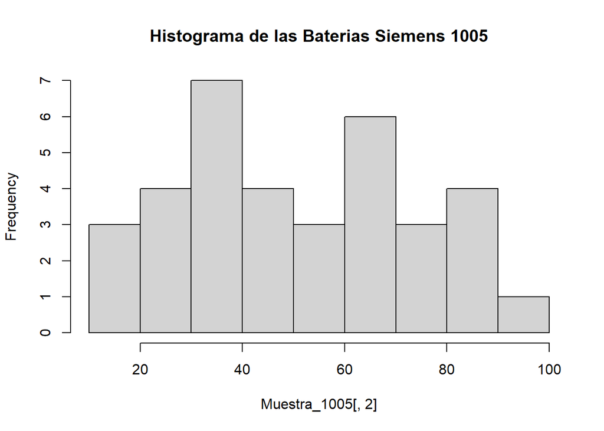

```r
hist(Muestra_1005[ ,2], main = "Histograma de las Baterias Siemens 1005")
```

Cálculo del promedio de la duracion de las baterias Siemens 1005

```r
vida_media_1005 <- mean(Muestra_1005[ ,2])
vida_media_1005
```

```
## [1] 52.14286
```

Cálculo del desvio estandar de la duracion de las baterias Siemens 1005

```r
vida_desv_1005 <- sd(Muestra_1005[ ,2])
vida_desv_1005
```

```
## [1] 22.77659
```

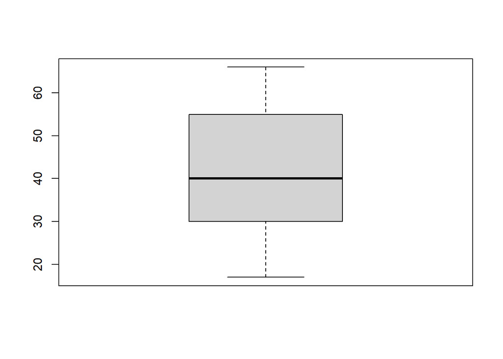

```r
boxplot(Muestra_75[ ,2])
```

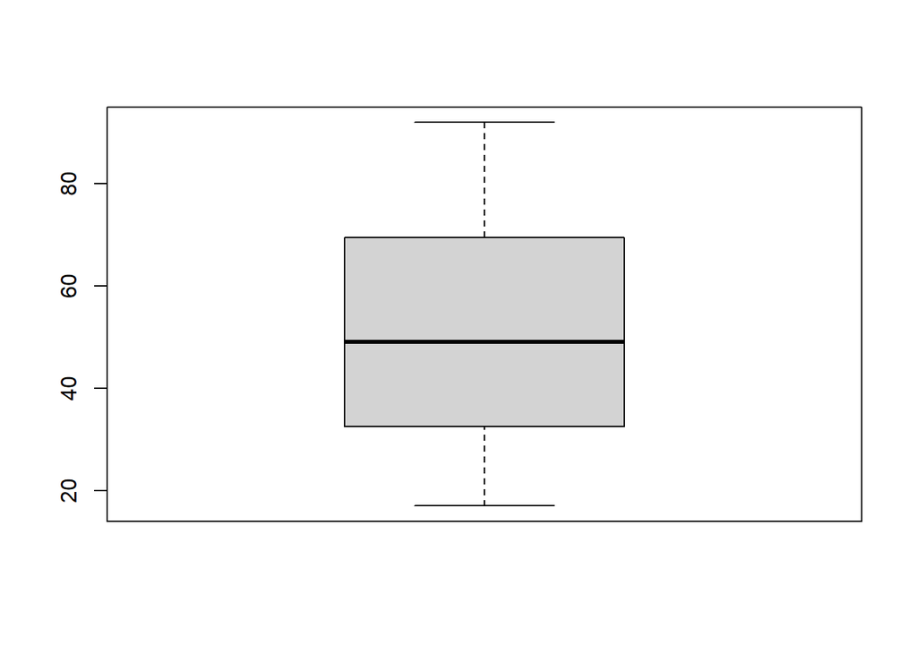

```r
boxplot(Muestra_1005[ ,2])
```

Muestra de Historial de Carga Baterias Varta 75

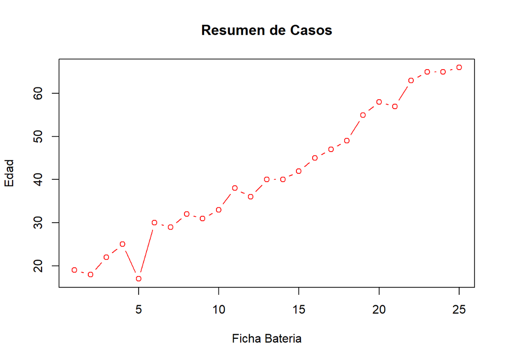

```r
plot(Muestra_75[ , 1:2],main = "Resumen de Casos",xlab = "Ficha Bateria",ylab="Edad", type="b", col="RED")
```

Muestra de Historial de Carga Baterias Siemens 1005

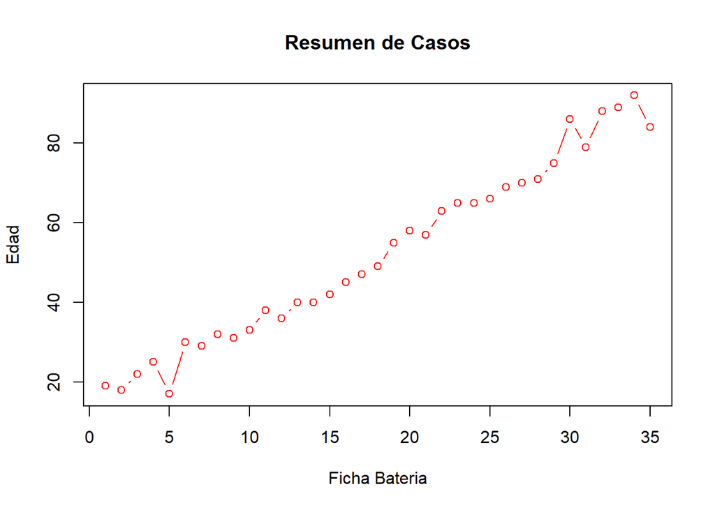

```r
plot(Muestra_1005[ , 1:2],main = "Resumen de Casos",xlab = "Ficha Bateria",ylab="Edad", type="b", col="RED")
```

Histograma de Edades de la Batería Varta 75

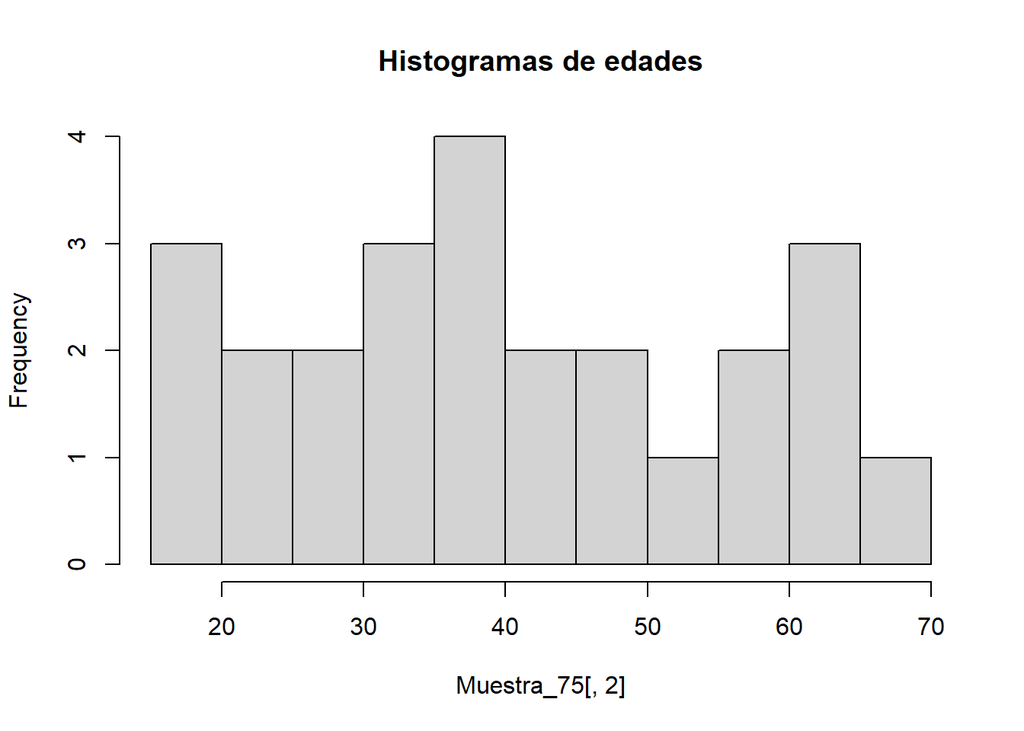

```r
hist(Muestra_75[ ,2],breaks = 10, main = "Histogramas de edades")
```

Histograma de Edades de la Batería Siemens 1005

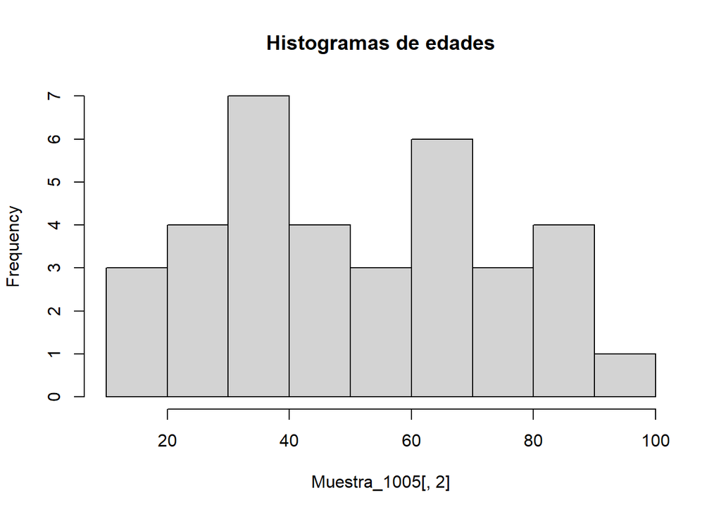

```r
hist(Muestra_1005[ ,2],breaks = 10, main = "Histogramas de edades")
```

Gráficos de Densidad Baterias Varta 75

```r
density(Muestra_75[ ,2])
```

```
##
## Call:
##  density.default(x = Muestra_75[, 2])
##
## Data: Muestra_75[, 2] (25 obs.); Bandwidth 'bw' = 7.394
##
##        x                y
##  Min.   :-5.183   Min.   :5.383e-05
##  1st Qu.:18.159   1st Qu.:2.474e-03
##  Median :41.500   Median :1.246e-02
##  Mean   :41.500   Mean   :1.070e-02
##  3rd Qu.:64.841   3rd Qu.:1.698e-02
##  Max.   :88.183   Max.   :2.186e-02
```

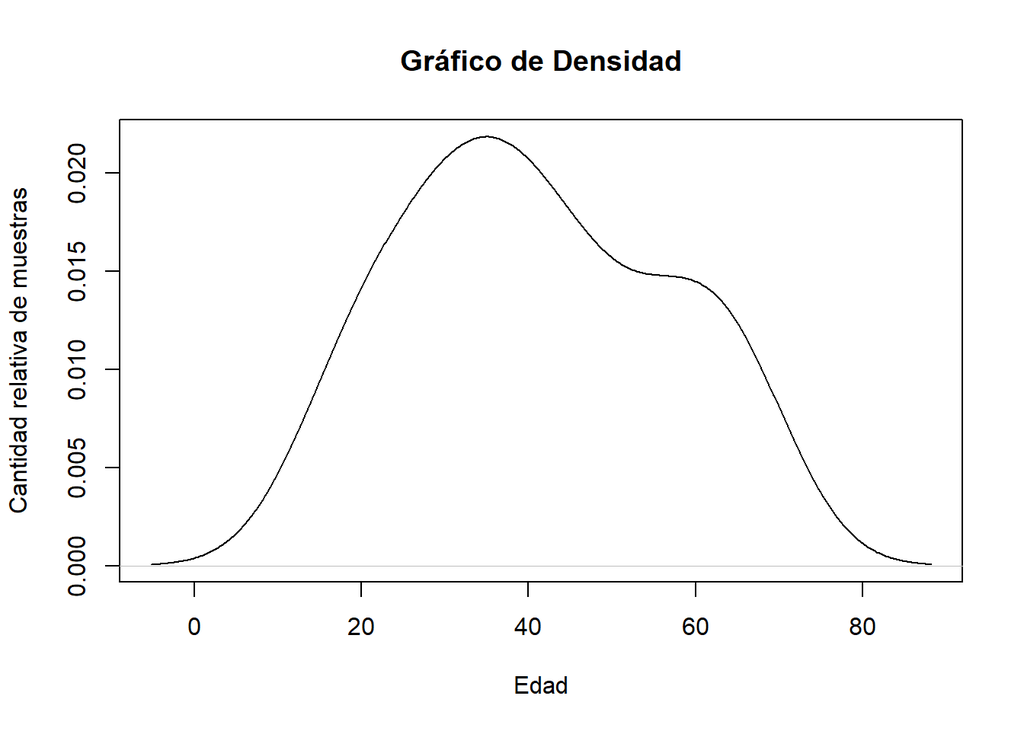

```r
plot(density(Muestra_75[ ,2]), main = "Gráfico de Densidad", ylab="Cantidad relativa de muestras",xlab="Edad")
```

Varianza de la Muestra Baterias 75

```r
var_muestra75 <- var(Muestra_75 [ ,2])
var_muestra75
```

```
## [1] 244.61
```

```r
n75 <- length(Muestra_75[ ,2])
n75
```

```
## [1] 25
```

```r
n_over_n_1 <- n75/(n75-1)
n_over_n_1
```

```
## [1] 1.041667
```

```r
var_poblacion75 <- var(Muestra_75[ ,2]) / n75
var_poblacion75
```

```
## [1] 9.7844
```

```r
vida_desv_75
```

```
## [1] 15.64001
```

```r
dsp75 <- sqrt(var_poblacion75)
dsp75
```

```
## [1] 3.128003
```

```r
dspp_75 <- dsp75/n75
dspp_75
```

```
## [1] 0.1251201
```

Gráficos de Densidad Baterias Siemens 1005

```r
density(Muestra_1005[ ,2])
```

```
##
## Call:
##  density.default(x = Muestra_1005[, 2])
##
## Data: Muestra_1005[, 2] (35 obs.);   Bandwidth 'bw' = 10.07
##
##        x                y
##  Min.   :-13.20   Min.   :2.409e-05
##  1st Qu.: 20.65   1st Qu.:1.550e-03
##  Median : 54.50   Median :8.491e-03
##  Mean   : 54.50   Mean   :7.377e-03
##  3rd Qu.: 88.35   3rd Qu.:1.229e-02
##  Max.   :122.20   Max.   :1.440e-02
```

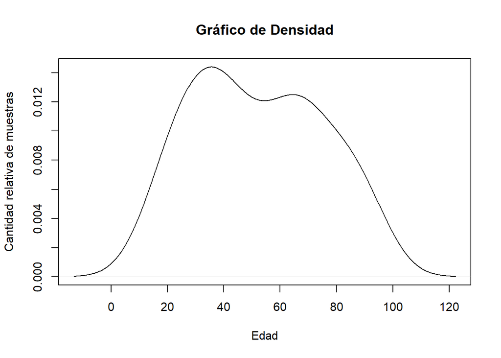

```r
plot(density(Muestra_1005[ ,2]), main = "Gráfico de Densidad", ylab="Cantidad relativa de muestras",xlab="Edad")
```

Varianza de la Muestra Baterias 1005

```r
var_muestra1005 <- var(Muestra_1005 [ ,2])
var_muestra1005
```

```
## [1] 518.7731
```

```r
n1005 <- length(Muestra_1005[ ,2])
n1005
```

```
## [1] 35
```

```r
n_over_n_2 <- n1005/(n1005-1)
n_over_n_2
```

```
## [1] 1.029412
```

```r
var_poblacion1005 <- var(Muestra_1005[ ,2]) / n1005
var_poblacion1005
```

```
## [1] 14.82209
```

```r
vida_desv_1005
```

```
## [1] 22.77659
```

```r
dsp1005 <- sqrt(var_poblacion1005)
dsp1005
```

```
## [1] 3.849947
```

```r
dspp_1005 <- dsp1005/n1005
dspp_1005
```

```
## [1] 0.1099985
```

Las Baterias Varta 75 tienen una duración Promedio de 40.88 ± 3.13 semanas

Las Baterias Siemens 1005 tienen una duración promedio de 52.14 ± 3.85 semanas